# Loan Data from Prosper Exploration

## Introduction

The dataset contains information on 113937 loan listings from Prosper, a loan company from 9th November, 2005 to 10th March, 2014. The dataset is made up of 81 columns containing information such as the listing keys, the date the loan was listed, loan status, etc. I will be exploring this dataset to derive insights.

## Preliminary Wrangling

```python
# import all packages and set plots to be embedded inline
import numpy as np
import pandas as pd
import matplotlib.pyplot as plt
import seaborn as sns

%matplotlib inline
```

### Loading in the dataset

```python
df = pd.read_csv('prosperLoanData.csv')
df.head()
```

|  | ListingKey | ListingNumber | ListingCreationDate | CreditGrade | Term | LoanStatus | ClosedDate | BorrowerAPR | BorrowerRate | LenderYield | ... | LP_ServiceFees | LP_CollectionFees | LP_GrossPrincipalLoss | LP_NetPrincipalLoss | LP_NonPrincipalRecoverypayments | PercentFunded | Recommendations | InvestmentFromFriendsCount | InvestmentFromFriendsAmount | Investors |
| --- | --- | --- | --- | --- | --- | --- | --- | --- | --- | --- | --- | --- | --- | --- | --- | --- | --- | --- | --- | --- | --- |
| 0 | 1021339766868145413AB3B | 193129 | 2007-08-26 19:09:29.263000000 | C | 36 | Completed | 2009-08-14 00:00:00 | 0.16516 | 0.1580 | 0.1380 | ... | -133.18 | 0.0 | 0.0 | 0.0 | 0.0 | 1.0 | 0 | 0 | 0.0 | 258 |
| 1 | 10273602499503308B223C1 | 1209647 | 2014-02-27 08:28:07.900000000 | NaN | 36 | Current | NaN | 0.12016 | 0.0920 | 0.0820 | ... | 0.00 | 0.0 | 0.0 | 0.0 | 0.0 | 1.0 | 0 | 0 | 0.0 | 1 |
| 2 | 0EE9337825851032864889A | 81716 | 2007-01-05 15:00:47.090000000 | HR | 36 | Completed | 2009-12-17 00:00:00 | 0.28269 | 0.2750 | 0.2400 | ... | -24.20 | 0.0 | 0.0 | 0.0 | 0.0 | 1.0 | 0 | 0 | 0.0 | 41 |
| 3 | 0EF5356002482715299901A | 658116 | 2012-10-22 11:02:35.010000000 | NaN | 36 | Current | NaN | 0.12528 | 0.0974 | 0.0874 | ... | -108.01 | 0.0 | 0.0 | 0.0 | 0.0 | 1.0 | 0 | 0 | 0.0 | 158 |
| 4 | 0F023589499656230C5E3E2 | 909464 | 2013-09-14 18:38:39.097000000 | NaN | 36 | Current | NaN | 0.24614 | 0.2085 | 0.1985 | ... | -60.27 | 0.0 | 0.0 | 0.0 | 0.0 | 1.0 | 0 | 0 | 0.0 | 20 |

5 rows × 81 columns

```python
df.duplicated().sum()
```

```
0
```

```python
df.shape
```

```
(113937, 81)
```

```python
df.info()
```

```
<class 'pandas.core.frame.DataFrame'>
RangeIndex: 113937 entries, 0 to 113936
Data columns (total 81 columns):
 #   Column                               Non-Null Count   Dtype
---  ------                               --------------   -----
 0   ListingKey                           113937 non-null  object
 1   ListingNumber                        113937 non-null  int64
 2   ListingCreationDate                  113937 non-null  object
 3   CreditGrade                          28953 non-null   object
 4   Term                                 113937 non-null  int64
 5   LoanStatus                           113937 non-null  object
 6   ClosedDate                           55089 non-null   object
 7   BorrowerAPR                          113912 non-null  float64
 8   BorrowerRate                         113937 non-null  float64
 9   LenderYield                          113937 non-null  float64
```

[output cut: 73 more lines]

```python
df['LoanStatus'].unique()
```

```
array(['Completed', 'Current', 'Past Due (1-15 days)', 'Defaulted',
       'Chargedoff', 'Past Due (16-30 days)', 'Cancelled',
       'Past Due (61-90 days)', 'Past Due (31-60 days)',
       'Past Due (91-120 days)', 'FinalPaymentInProgress',
       'Past Due (>120 days)'], dtype=object)
```

```python
df['ListingCategory (numeric)'] = df['ListingCategory (numeric)'].astype('category')
```

```python
df.info()
```

```
<class 'pandas.core.frame.DataFrame'>
RangeIndex: 113937 entries, 0 to 113936
Data columns (total 81 columns):
 #   Column                               Non-Null Count   Dtype
---  ------                               --------------   -----
 0   ListingKey                           113937 non-null  object
 1   ListingNumber                        113937 non-null  int64
 2   ListingCreationDate                  113937 non-null  object
 3   CreditGrade                          28953 non-null   object
 4   Term                                 113937 non-null  int64
 5   LoanStatus                           113937 non-null  object
 6   ClosedDate                           55089 non-null   object
 7   BorrowerAPR                          113912 non-null  float64
 8   BorrowerRate                         113937 non-null  float64
 9   LenderYield                          113937 non-null  float64
```

[output cut: 73 more lines]

### What is the structure of your dataset?

The dataset contained of 113,937 rows, 81 columns. The dataset contains 113,937 unique loan listings with zero duplicates.

### What is/are the main feature(s) of interest in your dataset?

I'm especially interested in finding out the factors that affect loan status. Like, are people with a certain employment status more likely to default on loans? Does a certain category of borrowers tend to default on their loans? I'm also interested in finding out factors that affect borrowers APR.

### What features in the dataset do you think will help support your investigation into your feature(s) of interest?

I'll be selecting columns of interest to reduce the size of the dataset

```python
df = df[['ListingKey', 'ListingCreationDate', 'Term', 'LoanStatus' ,'IncomeRange', 'BorrowerAPR', 'BorrowerRate', 'LenderYield', 'EstimatedReturn', 'ProsperRating (Alpha)', 'ListingCategory (numeric)', 'EmploymentStatus','CurrentCreditLines', 'CurrentDelinquencies', 'AmountDelinquent', 'DebtToIncomeRatio', 'OnTimeProsperPayments']]
df.head()
```

|  | ListingKey | ListingCreationDate | Term | LoanStatus | IncomeRange | BorrowerAPR | BorrowerRate | LenderYield | EstimatedReturn | ProsperRating (Alpha) | ListingCategory (numeric) | EmploymentStatus | CurrentCreditLines | CurrentDelinquencies | AmountDelinquent | DebtToIncomeRatio | OnTimeProsperPayments |
| --- | --- | --- | --- | --- | --- | --- | --- | --- | --- | --- | --- | --- | --- | --- | --- | --- | --- |
| 0 | 1021339766868145413AB3B | 2007-08-26 19:09:29.263000000 | 36 | Completed | $25,000-49,999 | 0.16516 | 0.1580 | 0.1380 | NaN | NaN | 0 | Self-employed | 5.0 | 2.0 | 472.0 | 0.17 | NaN |
| 1 | 10273602499503308B223C1 | 2014-02-27 08:28:07.900000000 | 36 | Current | $50,000-74,999 | 0.12016 | 0.0920 | 0.0820 | 0.05470 | A | 2 | Employed | 14.0 | 0.0 | 0.0 | 0.18 | NaN |
| 2 | 0EE9337825851032864889A | 2007-01-05 15:00:47.090000000 | 36 | Completed | Not displayed | 0.28269 | 0.2750 | 0.2400 | NaN | NaN | 0 | Not available | NaN | 1.0 | NaN | 0.06 | NaN |
| 3 | 0EF5356002482715299901A | 2012-10-22 11:02:35.010000000 | 36 | Current | $25,000-49,999 | 0.12528 | 0.0974 | 0.0874 | 0.06000 | A | 16 | Employed | 5.0 | 4.0 | 10056.0 | 0.15 | NaN |
| 4 | 0F023589499656230C5E3E2 | 2013-09-14 18:38:39.097000000 | 36 | Current | $100,000+ | 0.24614 | 0.2085 | 0.1985 | 0.09066 | D | 2 | Employed | 19.0 | 0.0 | 0.0 | 0.26 | 11.0 |

## Univariate Exploration

##### Lets start by looking at the distribution of numeric variables in the dataset

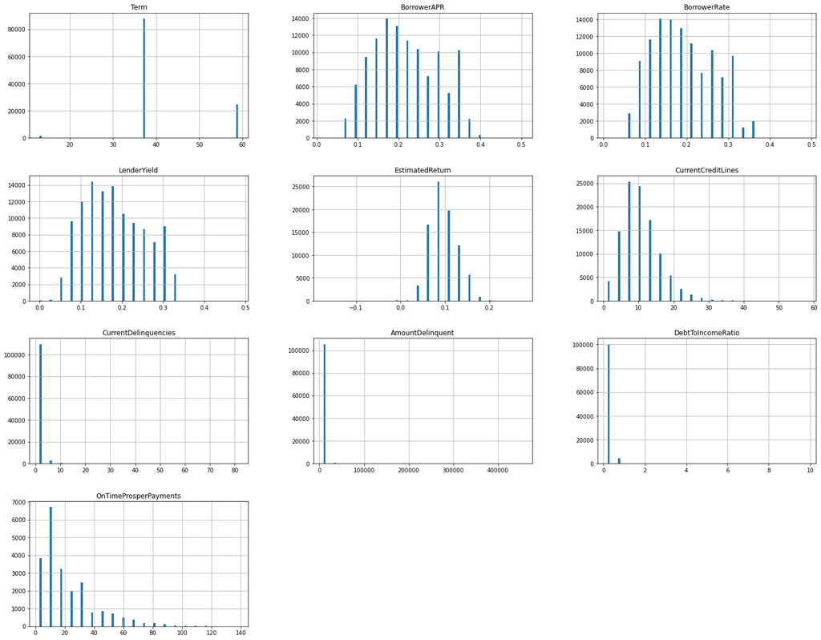

```python
fig, ax = plt.subplots(figsize=(25, 20))
df.select_dtypes('number').hist(ax=ax, bins=20, rwidth=0.2);
```

From the plot we can see that majority of the loans have 36 months(3 years) term. The Borrower APR ranges 0.1 - 0.4; same goes for Borrower Rate. Lender Yield ranges from 0 - a little above 0.3, Current Credit Lines ranges from 0 - about 40; with majority falling between 5 and 15 and so on.

Lets look at the decriptive statistics of this variables

```python
df.describe()
```

|  | Term | BorrowerAPR | BorrowerRate | LenderYield | EstimatedReturn | CurrentCreditLines | CurrentDelinquencies | AmountDelinquent | DebtToIncomeRatio | OnTimeProsperPayments |
| --- | --- | --- | --- | --- | --- | --- | --- | --- | --- | --- |
| count | 113937.000000 | 113912.000000 | 113937.000000 | 113937.000000 | 84853.000000 | 106333.000000 | 113240.000000 | 106315.000000 | 105383.000000 | 22085.000000 |
| mean | 40.830248 | 0.218828 | 0.192764 | 0.182701 | 0.096068 | 10.317192 | 0.592052 | 984.507059 | 0.275947 | 22.271949 |
| std | 10.436212 | 0.080364 | 0.074818 | 0.074516 | 0.030403 | 5.457866 | 1.978707 | 7158.270157 | 0.551759 | 18.830425 |
| min | 12.000000 | 0.006530 | 0.000000 | -0.010000 | -0.182700 | 0.000000 | 0.000000 | 0.000000 | 0.000000 | 0.000000 |
| 25% | 36.000000 | 0.156290 | 0.134000 | 0.124200 | 0.074080 | 7.000000 | 0.000000 | 0.000000 | 0.140000 | 9.000000 |
| 50% | 36.000000 | 0.209760 | 0.184000 | 0.173000 | 0.091700 | 10.000000 | 0.000000 | 0.000000 | 0.220000 | 15.000000 |
| 75% | 36.000000 | 0.283810 | 0.250000 | 0.240000 | 0.116600 | 13.000000 | 0.000000 | 0.000000 | 0.320000 | 32.000000 |
| max | 60.000000 | 0.512290 | 0.497500 | 0.492500 | 0.283700 | 59.000000 | 83.000000 | 463881.000000 | 10.010000 | 141.000000 |

Lets also look into the string variables. Lets begin by looking at the distribution of listing Category. I'll be using a seaborn countplot to visualize this

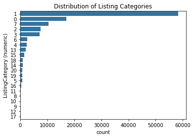

```python
sns.countplot(data=df, y='ListingCategory (numeric)', color=sns.color_palette()[0], order=df['ListingCategory (numeric)'].value_counts().index)
plt.title('Distribution of Listing Categories');
```

The plot clearly shows that majority of the loans taken fall into category 1 which represents debt consolidation. This is quite contrary to the believe I held that majority of the loans would fall in the business category. This is Followed by category 0, Not available, other, Home Improvement and Business.

Lets go ahead to look at the distribution of Loan status which represents the current loan status of the loans

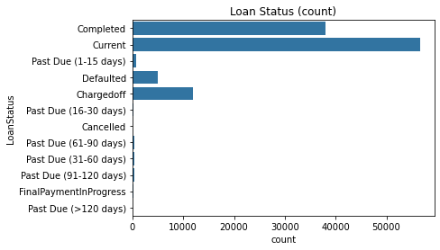

```python
sns.countplot(data=df, y='LoanStatus', color=sns.color_palette()[0])
plt.title('Loan Status (count)');
```

Charged off loans are defaulted loans in which the lender has given up all hope of recovering. So, I'm going to merge it into defaulted loans to simplify the plot. Also, I am going to merge all past due loans together.

```python
a = []
complete = ['Completed', 'Current','Cancelled' ,'FinalPaymentInProgress']
for stat in df['LoanStatus']:
    if stat in complete:
        a.append(stat)
    elif stat == 'Defaulted' or stat == 'Chargedoff':
        a.append('Defaulted')
    else:
        a.append("Past Due")
df['LoanStatus_m'] = a
```

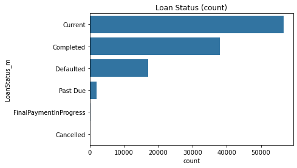

```python
sns.countplot(data=df, y='LoanStatus_m', color=sns.color_palette()[0], order=df['LoanStatus_m'].value_counts().index)
plt.title('Loan Status (count)');
```

From this plot, we can see more clearly that majority of the loans are Current, followed by Completed Loans then defaulted and past due. Further on, I'll look more closely at defaulted loans and past due loans.

Lets now look at employment status

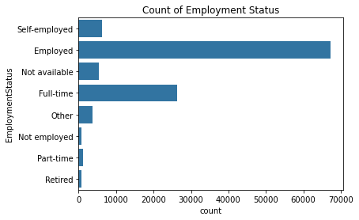

```python
sns.countplot(data=df, y='EmploymentStatus', color=sns.color_palette()[0])
plt.title('Count of Employment Status');
```

Majority of the borrowers are employed, a small portion is unemployed, while some employment status is unavailable.

Lets now into the prosper rating. Prosper rating is a rating assigned to each loan gotten from Prosper. The rating represents an estimated average annualized loss rate range. "The estimated loss rate is based on the historical performance of Prosper loans with similar characteristics". Below is a table that represents the ratings and average annual loss range gotten from the prosper website.

| Prosper Rating | Estimated Avg. Annual Loss Rate** |
| --- | --- |
| AA | 0.00-1.99% |
| A | 2.00–3.99% |
| B | 4.00–5.99% |
| C | 6.00–8.99% |
| D | 9.00–11.99% |
| E | 12.00–14.99% |
| HR | ≥ 15.00% |

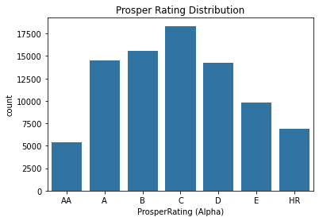

```python
sns.countplot(data=df, x='ProsperRating (Alpha)', order=['AA', 'A', 'B', 'C', 'D', 'E', 'HR'], color=sns.color_palette()[0])
plt.title('Prosper Rating Distribution');
```

We can see from the plot above that majority of the borrowers fall into the C category with an estimated annual loss rate of 6.00–8.99%. The plot is also normally distributed with the two extreme categories possessing the least counts.

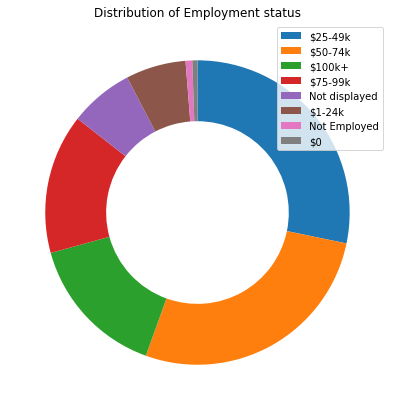

```python
fig, ax = plt.subplots(figsize=(50, 7))
labels = ['$25-49k', '$50-74k', '$100k+','$75-99k','Not displayed','$1-24k', 'Not Employed', '$0']
plt.pie( x=df['IncomeRange'].value_counts(),
        #labels=labels,
        startangle = 90,
        counterclock = False,
        rotatelabels=True,
        wedgeprops = {'width' : 0.4})
plt.legend(labels)
plt.xticks(rotation=95)
plt.title('Distribution of Employment status');
```

With the plot we can see that majority of the borrowers fall into an income range of 25 - 100k dollars.

```python
df['LoanStatus_m'].value_counts()
```

```
Current                   56576
Completed                 38074
Defaulted                 17010
Past Due                   2067
FinalPaymentInProgress      205
Cancelled                     5
Name: LoanStatus_m, dtype: int64
```

### Discuss the distribution(s) of your variable(s) of interest. Were there any unusual points? Did you need to perform any transformations?

Majority of the loans in the are current, followed by Completed. Defaulted and Charged off loans sums upto 17,010 of the total loans while loans that are past due made up 2067 of the loans. To make it easier to work with I had to merge all past due loans together and also merge charged off loans with defaulted loans in a new column called "LoanStatus_m". The borrower APR ranges from about 0.1 to 0.4

## Bivariate Exploration

### Question 1: What are the factors that affect Loan status?

#### i. How does employment status affect Loan status (default)?

To answer this question, lets plot a clustered countplot of loan status and Employment status

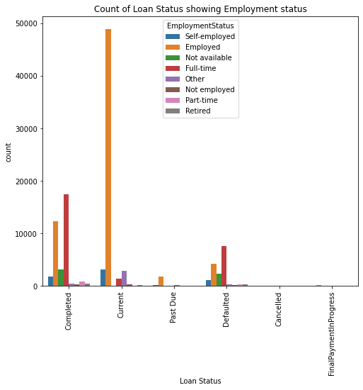

```python
fig, ax = plt.subplots(figsize=(8, 7))
sns.countplot(data=df, x='LoanStatus_m', hue='EmploymentStatus')
plt.xticks(rotation=90)
plt.title('Count of Loan Status showing Employment status')
plt.xlabel('Loan Status');
```

From the plot we can see that majority of loan defaulters in the dataset are fulltime workers followed by employed While past due is barely seen. Lets subset the dataset for where loan status is past due or defaulted to plot so we can see more clearly.

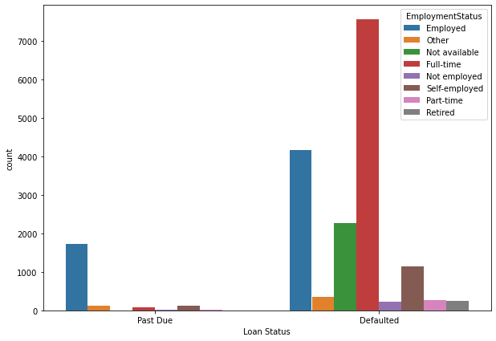

```python
default = df[df['LoanStatus_m'].isin(['Defaulted', 'Past Due'])]
fig, ax = plt.subplots(figsize=(10, 7))
sns.countplot(data=default, x='LoanStatus_m', hue='EmploymentStatus')
plt.xlabel('Loan Status');
```

In the above visualization, we can see more clearly that majority of people whose loans are past due are employed. But is it that employed people tend to be defaulters or fail to payup thier loans on time or are they just the majority in the dataset leading to their larger count? Lets look into this. To do this I'm going to create a dataframe of employment status and the percent of defaulters including those whose loans have past due.

```python
d = default['EmploymentStatus'].value_counts()
d
```

```
Full-time        7631
Employed         5884
Not available    2269
Self-employed    1256
Other             467
Part-time         270
Retired           244
Not employed      243
Name: EmploymentStatus, dtype: int64
```

```python
b = []
a = []
for i in d.index:
    b.append((d[i] / len(df[df['EmploymentStatus'] == i]))*100)
    a.append(i)
```

```python
defaulters = pd.DataFrame(a)
defaulters.columns=['EmploymentStatus']
defaulters['PercentOfTotal'] = b
defaulters = defaulters.sort_values(by='PercentOfTotal', ascending=False)
defaulters
```

|  | EmploymentStatus | PercentOfTotal |
| --- | --- | --- |
| 2 | Not available | 42.435010 |
| 6 | Retired | 30.691824 |
| 7 | Not employed | 29.101796 |
| 0 | Full-time | 28.954658 |
| 5 | Part-time | 24.816176 |
| 3 | Self-employed | 20.476035 |
| 4 | Other | 12.270100 |
| 1 | Employed | 8.740085 |

```python
defaulters.to_csv('defaulters.csv')
```

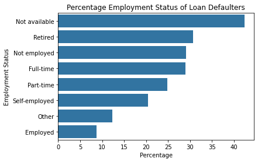

```python
sns.barplot(data=defaulters, y='EmploymentStatus', x='PercentOfTotal', color=sns.color_palette()[0])
plt.title('Percentage Employment Status of Loan Defaulters')
plt.xlabel('Percentage')
plt.ylabel('Employment Status');
```

With the above visualization we can see that although we had a large number of employed people who had defaulted on their loans as shown in the previous visualizations, it was was merely because of their large proportion in the dataset. The visual above shows that about 40% of persons whose employment status were unavailable defaulted on their loans, followed by retired with about 30% and not employed with also about 30%.

So, to answer our question we can say that employment status does affect loan status. As the chart above clearly that most employed people pay up their loans

#### ii. Does a higher Annual Percentage Rate (APR) contribute to loan default?

To answer this question, I'll make use of a boxplot

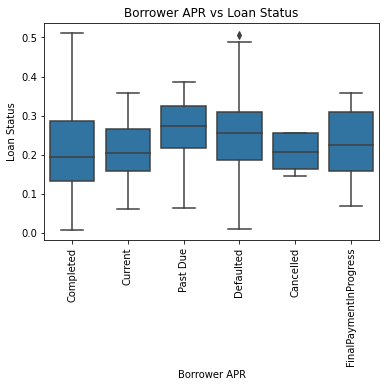

```python
sns.boxplot(data=df, x='LoanStatus_m', y='BorrowerAPR',color=sns.color_palette()[0])
plt.xticks(rotation=90)
plt.title('Borrower APR vs Loan Status')
plt.ylabel('Loan Status')
plt.xlabel('Borrower APR');
```

Let us go ahead to visualize the relationship between Borrower Rate (Interest Rate) and Loan status. The APR is different from the Interest rate because while interest rate is the percentage of interest paid on a loan, APR includes the interest rate as well as any additional fees or expenses you'll pay to your lender.

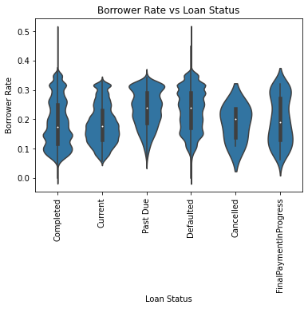

```python
sns.violinplot(data=df, x='LoanStatus_m', y='BorrowerRate', color=sns.color_palette()[0])
plt.xticks(rotation=90)
plt.title('Borrower Rate vs Loan Status')
plt.ylabel('Borrower Rate')
plt.xlabel('Loan Status');
```

Here we can also see that defaulted loans and Past due loans have a higher median interest rate of about 25%. And also, looking at the relationship between Lender Yield and Loan Status from the visualization below we can also see that median lender yield for past due and defaulted loans are higher.

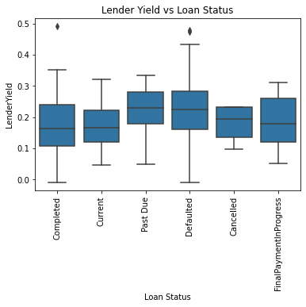

```python
sns.boxplot(data=df, x='LoanStatus_m', y='LenderYield',color=sns.color_palette()[0])
plt.xticks(rotation=90)
plt.title('Lender Yield vs Loan Status')
plt.xlabel('Loan Status');
```

#### iii. Does the number of accounts delinquent affect the loan outcome?

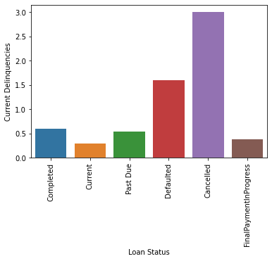

```python
sns.barplot(data=df, x='LoanStatus_m', y='CurrentDelinquencies', ci=None)
plt.xticks(rotation=90)
plt.xlabel('Loan Status')
plt.ylabel('Current Delinquencies');
```

### Question 2: What are the factors that affect Borrower APR?

#### i. Does the APR increase with Income?

To answer this question, I will make use of a boxplot.

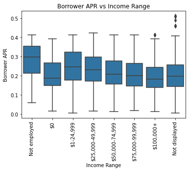

```python
order=['Not employed', '$0', '$1-24,999', '$25,000-49,999', '$50,000-74,999', '$75,000-99,999', '$100,000+', 'Not displayed']
sns.boxplot(data=df, x='IncomeRange', y='BorrowerAPR', order=order,color=sns.color_palette()[0])
plt.xticks(rotation=90)
plt.ylabel('Borrower APR')
plt.xlabel('Income Range')
plt.title('Borrower APR vs Income Range');
```

Above, we can see that median Borrower APR decreases with increase in Income. Therefore, APR does not increase with income. Rather it tends to decrease as income increases.

#### iii. Does the prosper rating affect the APR?

Lets answer this question by plotting a barchart

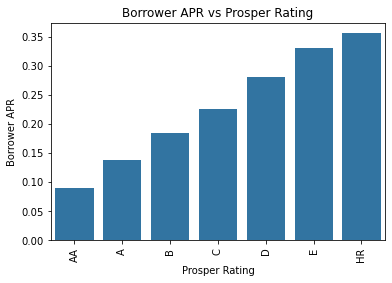

```python
sns.barplot(x=df['ProsperRating (Alpha)'], y=df['BorrowerAPR'], order=['AA', 'A', 'B', 'C', 'D', 'E', 'HR'], ci=None,color=sns.color_palette()[0])
plt.xticks(rotation=90)
plt.title('Borrower APR vs Prosper Rating')
plt.ylabel('Borrower APR')
plt.xlabel('Prosper Rating');
```

From the above visual it is clear that borrower APR increases as the estimated average annualized loss rate range increases. Listings rated AA which represents the lowest risk has lower mean APR while HR the highest risk has the highest APR. So the higher estimated average annualized loss rate range the higher the APR.

#### Lets explore the relationship between APR and other numeric variables in the dataset

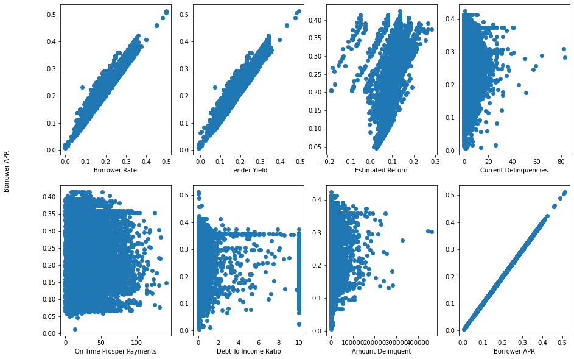

```python
fig, ax = plt.subplots(2, 4, figsize=(15, 10))
ax[0, 0].scatter(x=df['BorrowerRate'], y=df['BorrowerAPR'])
ax[0, 0].set_xlabel('Borrower Rate')
ax[0, 1].scatter(x=df['LenderYield'], y=df['BorrowerAPR'])
ax[0, 1].set_xlabel('Lender Yield')
ax[0, 2].scatter(x=df['EstimatedReturn'], y=df['BorrowerAPR'])
ax[0, 2].set_xlabel('Estimated Return')
ax[0, 3].scatter(x=df['CurrentDelinquencies'], y=df['BorrowerAPR'])
ax[0, 3].set_xlabel('Current Delinquencies')
ax[1, 0].scatter(x=df['OnTimeProsperPayments'], y=df['BorrowerAPR'])
ax[1, 0].set_xlabel('On Time Prosper Payments')
ax[1, 1].scatter(x=df['DebtToIncomeRatio'], y=df['BorrowerAPR'])
ax[1, 1].set_xlabel('Debt To Income Ratio')
ax[1, 2].scatter(x=df['AmountDelinquent'], y=df['BorrowerAPR'])
ax[1, 2].set_xlabel('Amount Delinquent')
ax[1, 3].scatter(x=df['BorrowerAPR'], y=df['BorrowerAPR'])
ax[1, 3].set_xlabel('Borrower APR')

fig.text(0.04, 0.5, 'Borrower APR', va='center', rotation='vertical');
```

From the above, we can see that APR has a strong positive correlation with borrower rate, lender yield and estimated return and a moderate to low correlation with current delinquencies, on time prosper payments, amount delinquent and debt to income ratio.

### How did the feature(s) of interest vary with other features in the dataset?

Through our investigation, we were able to find that Defaulted loans has higher APR, Borrower rate and lender yield. It was also found to have high current delinquencies. APR was found to have a negative relationship with Income, and a positive relationship with prosper rating, borrower rate, lender yield, and estimated yield.

## Multivariate Exploration

We've seen how APR is ditributed among different income range. Lets take a close look at this. Does income range have a strong influence on APR? I'm going to go ahead and plot a boxplot of Borrower APR and Income Range across different loan status.

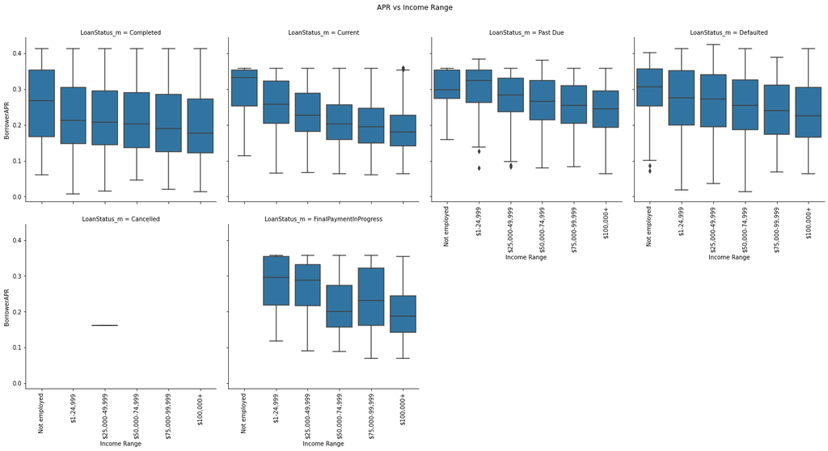

```python
order=['Not employed', '$1-24,999', '$25,000-49,999', '$50,000-74,999', '$75,000-99,999', '$100,000+']
g = sns.catplot(x="IncomeRange", y="BorrowerAPR", kind='box',
                col="LoanStatus_m", col_wrap=4, data=df, order=order,color=sns.color_palette()[0])

g.set_xticklabels(rotation=90)
g.set_xlabels('Income Range')

g.fig.subplots_adjust(top=0.9)
g.fig.suptitle('APR vs Income Range');
```

Now, lets look at current delinquencies as one of these factors.

[figure not shown]

```python
order=['Not employed', '$1-24,999', '$25,000-49,999', '$50,000-74,999', '$75,000-99,999', '$100,000+']
g = sns.catplot(x="IncomeRange", y="BorrowerAPR", kind='box',
                col="CurrentDelinquencies", col_wrap=4, data=df,color=sns.color_palette()[0], order=order)

g.set_xlabels('Loan Status')
g.set_xticklabels(rotation=90)

#g.fig.subplots_adjust(top=0.9)
#g.fig.suptitle('APR vs Loan Status');
```

Here, we can see the decrease in APR as income increases. We can also see the increase in APR as the number of current delinquencies increases. So we can safely say that the number of delinquencies is considered when setting APRs.

```python
df_corr = df.copy()
```

Lets look at the correlation between our variables of interest. To do this, I'll have to encode string variables as numbers. I'll begin by replacing "Not displayed" in IncomeRange column with NaN and also replacing "Not available" in EmploymentStatus column with NaN.

```python
df_corr['IncomeRange'] = df_corr['IncomeRange'].replace('Not displayed', np.nan)
df_corr['EmploymentStatus'] = df_corr['EmploymentStatus'].replace('Not available', np.nan)
```

Now, I'll create ordered lists of categories in LoanStatus, IncomeRange, ProsperRating and EmploymentStatus. I'll then write a function that uses this list to replace the content with the index.

```python
#Ordered arrays used in encoding variables
loan_status = ['Cancelled', 'Current', 'Completed', 'FinalPaymentInProgress', 'Past Due', 'Defaulted']
income_range = ['Not employed', '$0', '$1-24,999', '$25,000-49,999', '$50,000-74,999','$75,000-99,999', '$100,000+']
prosper_rating = ['AA', 'A', 'B', 'C', 'D', 'E', 'HR']
employment_status = ['Not employed', 'Other', 'Part-time', 'Retired', 'Self-employed', 'Employed', 'Full-time']
```

```python
#Function to encode categories
def cat (arr, col):
    for i in range(len(arr)):
        df_corr[col].replace(arr[i], i, inplace=True)
```

```python
# Calling functions
cat(loan_status, 'LoanStatus_m')
cat(income_range, 'IncomeRange')
cat(prosper_rating, 'ProsperRating (Alpha)')
cat(employment_status, 'EmploymentStatus')
```

```python
corr =  df_corr[['LoanStatus_m', 'EmploymentStatus', 'IncomeRange', 'ProsperRating (Alpha)', 'BorrowerAPR', 'ListingCategory (numeric)', 'CurrentDelinquencies']].corr()
corr
```

|  | LoanStatus_m | EmploymentStatus | IncomeRange | ProsperRating (Alpha) | BorrowerAPR | CurrentDelinquencies |
| --- | --- | --- | --- | --- | --- | --- |
| LoanStatus_m | 1.000000 | 0.135527 | -0.167861 | 0.233559 | 0.173173 | 0.218080 |
| EmploymentStatus | 0.135527 | 1.000000 | 0.213164 | -0.097029 | -0.111761 | 0.051393 |
| IncomeRange | -0.167861 | 0.213164 | 1.000000 | -0.255295 | -0.196177 | -0.050347 |
| ProsperRating (Alpha) | 0.233559 | -0.097029 | -0.255295 | 1.000000 | 0.962151 | 0.145205 |
| BorrowerAPR | 0.173173 | -0.111761 | -0.196177 | 0.962151 | 1.000000 | 0.149404 |
| CurrentDelinquencies | 0.218080 | 0.051393 | -0.050347 | 0.145205 | 0.149404 | 1.000000 |

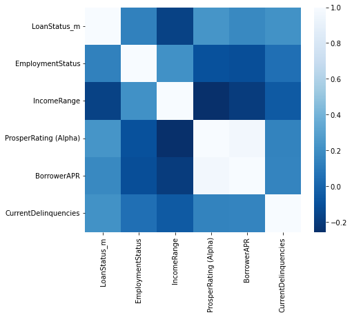

```python
fig, ax = plt.subplots(figsize=(7,6))
sns.heatmap(corr, cmap="Blues_r");
```

## Conclusion

In this Analysis, I was interested in finding out factors that affect the loan status particularly defaulted loans and also factors that affect the borrowers APR. The dataset used for this analysis was clean so much wrangling operations were not carried out. To answer the questions I posed, I made use of various charts like barcharts, histograms, box plots, etc. I was able to come up with the following conclusions:

1. Most of the loan listings in the dataset was for debt consolidation.
2. Defaulted loans are associated with high APR. This was further investigated to find that the higher the Estimated Avg. Annual Loss Rate which is represented by Prosper ratings, the higher the APR. So loans with high APR are high risk loans.
3. Individuals with higher and stable income received lower APR on their loans.
4. Most employed individuals do not default on their loans.

```python
df.to_csv('df_clean.csv')
df_corr.to_csv('df_corr.csv')
```